# Statistical Inference and Publication Bias

### Hypothesis testing

Compare an experimental group and a control group.

$H_0$: Null hypothesis.  
No difference between the groups.

$$\mu_{exp} - \mu_{ctrl} = 0$$

$H_A$: Alternative hypothesis.  
Statistically significant difference between the groups

$$\mu_{exp} - \mu_{ctrl} \neq 0$$

“Difference” defined in terms of some **test statistic**.  
(different means (eg t-test), different variances (eg F-test))

Groups defined through careful experimental design  
randomisation, blinded, double blinded

### Effect Size

it is the standardised mean difference

$$ES=\dfrac{X_1-X_2}{\sigma_\mathrm{pooled}}$$

It is the same as the $Z$-score, or $T$-score.

Different ways to calculate $\sigma_\mathrm{pooled}$ eg take $\sigma$ of control group.

### Cohen's Heuristic

Standardised mean difference effect size

- small 0.2
- medium 0.5
- large 0.8

### Confidence Interval (off effect size)

What does a 95% confidence interval of the effect size mean?

- If we repeated the experiment 100 times than we expect that the interval will contains the observed effect size 95/100 times
- If the confidence interval includes zero, then this is equivalent ot saying that the result is not statistically significant.

### Reason 2: Mistakes and Fraud (Reason 2)

Van Noorden, R. (2011). Science publishing: The trouble with retractions. Nature, 478(7367), 26-28. doi:10.1038/478026a

- From 2001-2011:10X increase in retractions but only 1.44X increase in papers.

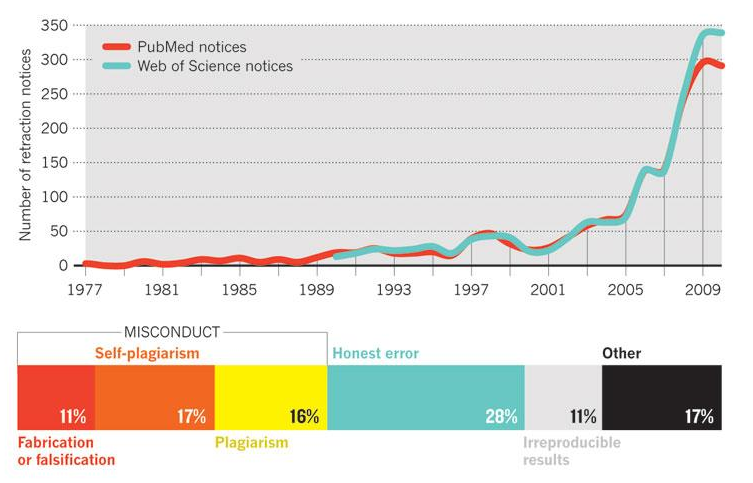

### Example of method to detect fraud

Benford's law: distribution of 1st digit of data.

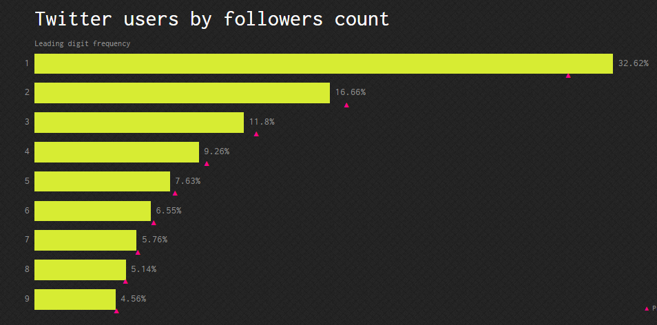

src: http://www.testingbenfordslaw.com/